# Lab 02 - Plastic waste

Qilin Zhang

1/13/2023

## Load packages and data

```r
library(tidyverse)
```

```r
plastic_waste <- read.csv("data/plastic-waste.csv")
```

## Exercises

ggplot(data = plastic_waste, aes(x = plastic_waste_per_cap)) + geom_histogram(binwidth = 0.2)

plastic_waste %>% filter(plastic_waste_per_cap > 3.5)

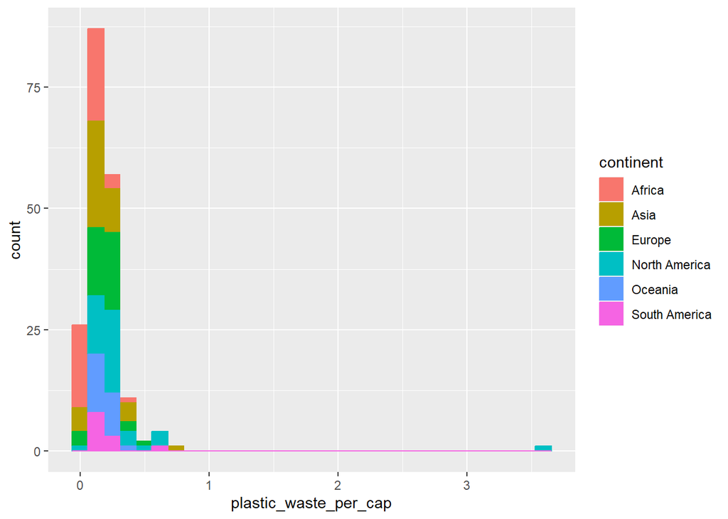

```r
ggplot(data = plastic_waste,mapping = aes(x = plastic_waste_per_cap, color = continent, fill = continent))+
geom_histogram()
```

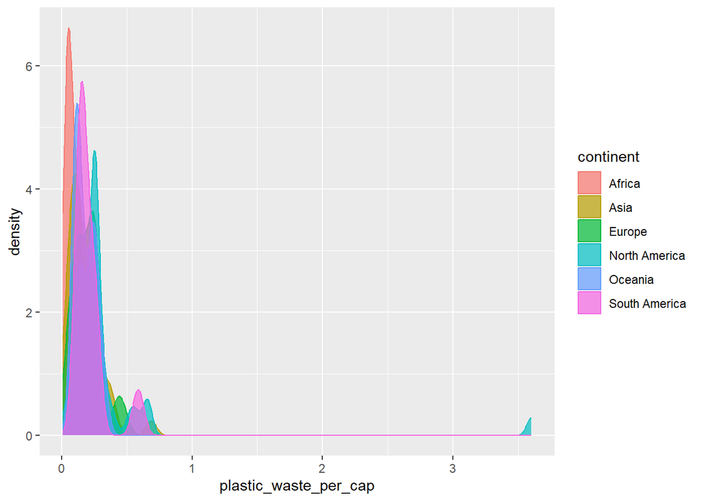

```r
ggplot(data = plastic_waste,mapping = aes(x = plastic_waste_per_cap, color = continent, fill = continent))+
geom_density(alpha = 0.7)
```

Data from each continent is similar with an exception of North America. It has a significant positive outlier (Trinidad and Tobago).

### Exercise 2

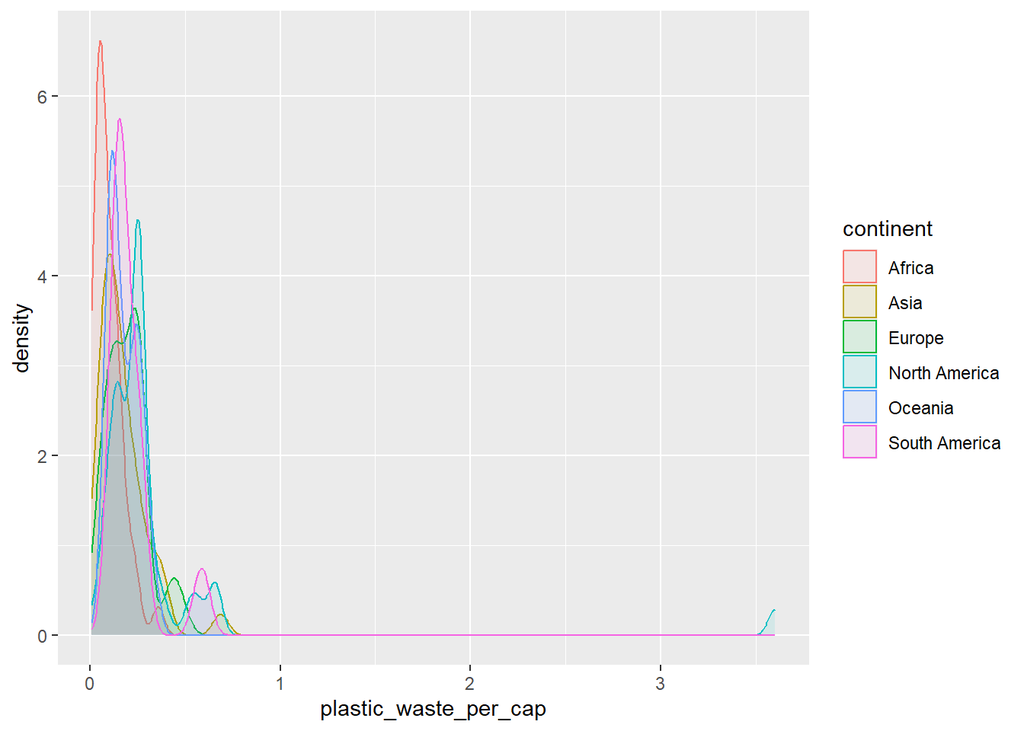

```r
#2.1
ggplot(data = plastic_waste,mapping = aes(x = plastic_waste_per_cap, color = continent, fill = continent))+
geom_density(alpha = 0.1)
```

### Exercise 3

The reason why we put “color” and “fill” in mapping instead of “geom_point” is that we hope to separate the data by the variable “continent” in later graphs. If we add “color” to the “geom——xxx”, it will tell R to fit color to the plot generated by all the data (without being categorized by “continent”). This would not accomplish the goal of comparing across continents and will likely be unachievable because of the nature of density plot.

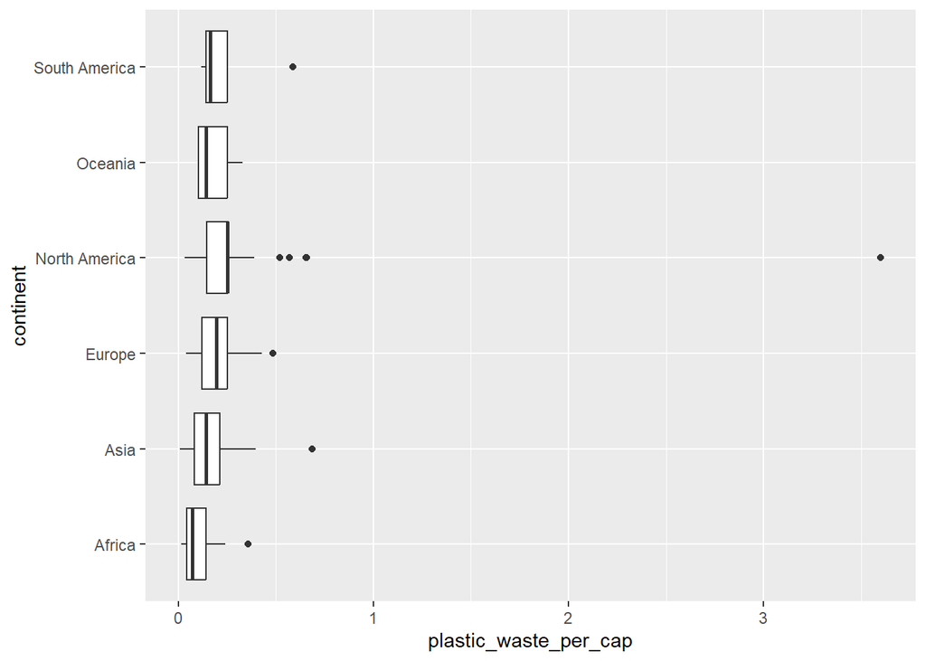

```r
ggplot(data = plastic_waste,mapping = aes(x = plastic_waste_per_cap, y = continent))+
geom_boxplot()
```

### Exercise 4

Violin plot reveals the frequency of plastic waste per cap. We can better see the concentration of the same plastic waste per cap better compared to box plot.

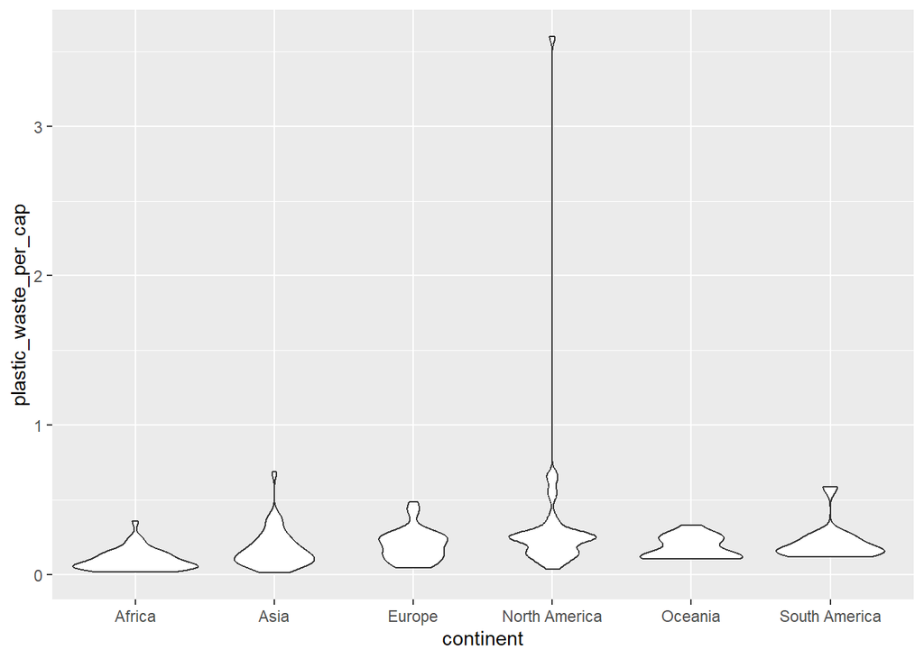

```r
ggplot(data = plastic_waste,mapping = aes(x = continent , y = plastic_waste_per_cap))+
geom_violin()
```

### Exercise 5

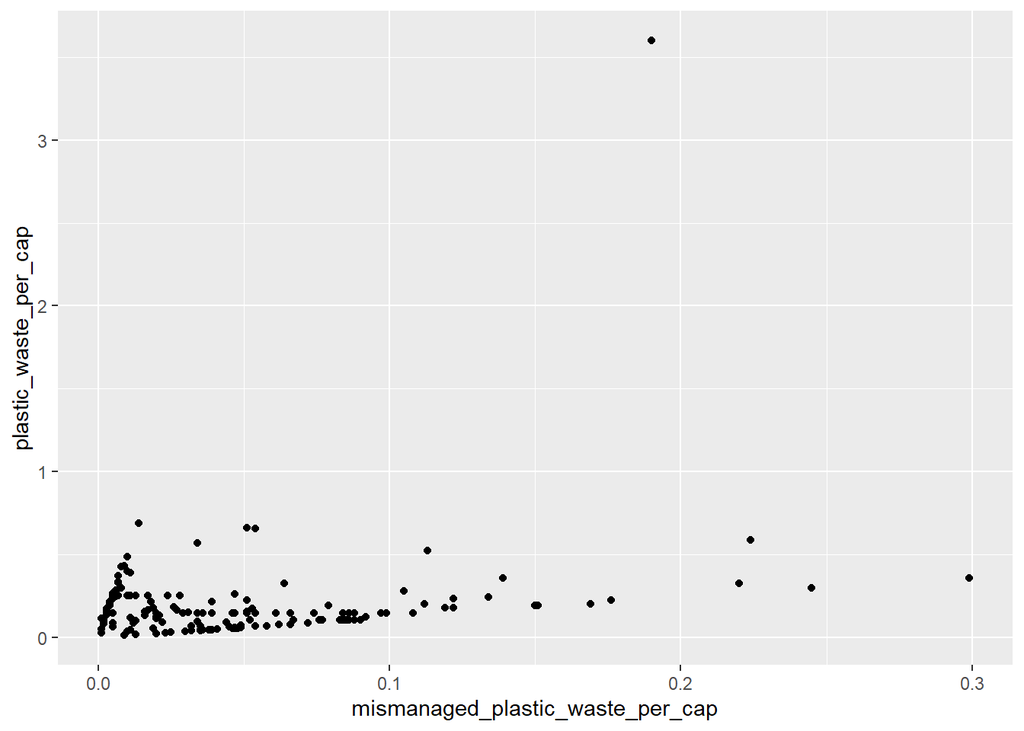

```r
# raw data
ggplot(data = plastic_waste, aes(x = mismanaged_plastic_waste_per_cap , y = plastic_waste_per_cap))+
geom_point()
```

```r
regression <- lm(mismanaged_plastic_waste_per_cap~plastic_waste_per_cap, data =plastic_waste)
summary(regression)
```

```
##
## Call:
## lm(formula = mismanaged_plastic_waste_per_cap ~ plastic_waste_per_cap,
##     data = plastic_waste)
##
## Residuals:
##      Min       1Q   Median       3Q      Max
## -0.05092 -0.04027 -0.00962  0.02193  0.24746
##
## Coefficients:
##                       Estimate Std. Error t value Pr(>|t|)
## (Intercept)           0.037017   0.004332   8.544 4.49e-15 ***
## plastic_waste_per_cap 0.040677   0.012771   3.185   0.0017 **
## ---
## Signif. codes:  0 '***' 0.001 '**' 0.01 '*' 0.05 '.' 0.1 ' ' 1
##
## Residual standard error: 0.04855 on 187 degrees of freedom
##   (因为不存在，51个观察量被删除了)
## Multiple R-squared:  0.05146,    Adjusted R-squared:  0.04639
## F-statistic: 10.14 on 1 and 187 DF,  p-value: 0.001696
```

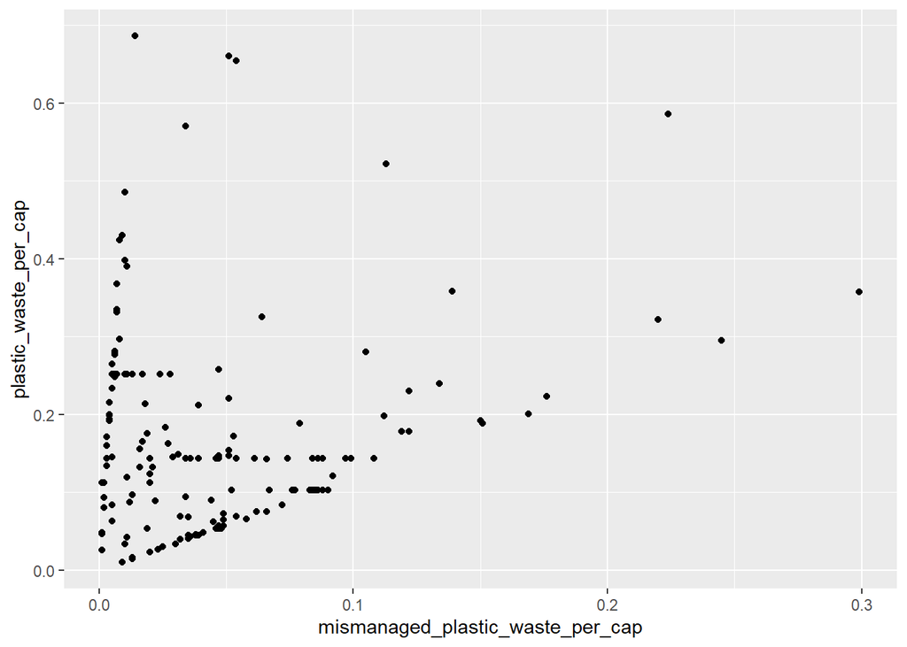

```r
rm(regression)


data <- plastic_waste %>%
  filter(plastic_waste_per_cap <3.5)

ggplot(data = data, aes(x = mismanaged_plastic_waste_per_cap , y = plastic_waste_per_cap))+
geom_point()
```

```r
regression <- lm(mismanaged_plastic_waste_per_cap~plastic_waste_per_cap, data =data)
summary(regression)
```

```
##
## Call:
## lm(formula = mismanaged_plastic_waste_per_cap ~ plastic_waste_per_cap,
##     data = data)
##
## Residuals:
##       Min        1Q    Median        3Q       Max
## -0.046833 -0.040115 -0.009316  0.021586  0.248923
##
## Coefficients:
##                       Estimate Std. Error t value Pr(>|t|)
## (Intercept)           0.038406   0.006283   6.112 5.64e-09 ***
## plastic_waste_per_cap 0.032692   0.029061   1.125    0.262
## ---
## Signif. codes:  0 '***' 0.001 '**' 0.01 '*' 0.05 '.' 0.1 ' ' 1
##
## Residual standard error: 0.04866 on 186 degrees of freedom
## Multiple R-squared:  0.006758,   Adjusted R-squared:  0.001418
## F-statistic: 1.266 on 1 and 186 DF,  p-value: 0.2621
```

```r
rm(regression)
rm(data)
```

### Exercise 6

There are no clear sign of differentiation between continents except for one outlier for North America.

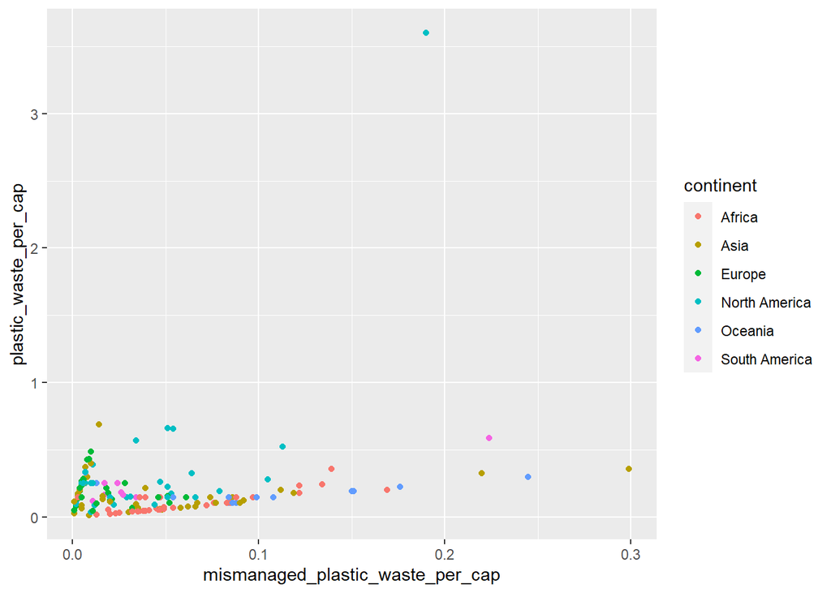

```r
ggplot(data = plastic_waste,mapping = aes(x = mismanaged_plastic_waste_per_cap , y = plastic_waste_per_cap, color= continent))+
geom_point()
```

### Exercise 7

Two pairs of variables show similar relationship with each others. Their r values are all around -0.07.

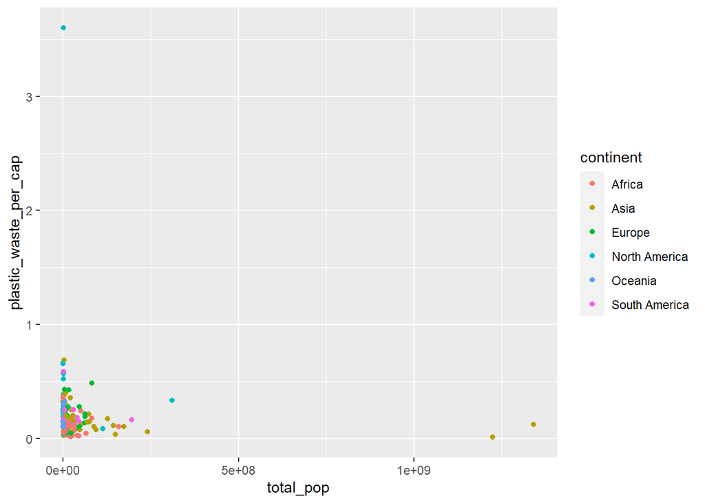

```r
ggplot(data = plastic_waste,mapping = aes(x = total_pop , y = plastic_waste_per_cap, color= continent))+
geom_point()
```

```r
cor(plastic_waste$plastic_waste_per_cap, plastic_waste$total_pop, use = "pairwise.complete.obs")
```

```
## [1] -0.07318113
```

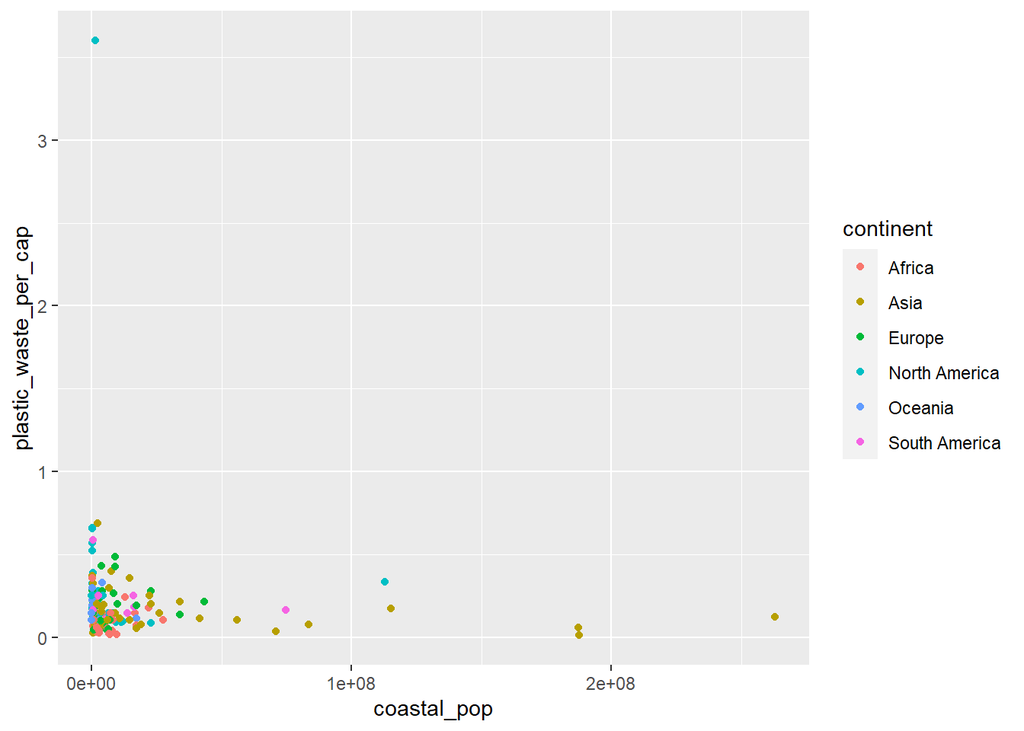

```r
ggplot(data = plastic_waste,mapping = aes(x = coastal_pop , y = plastic_waste_per_cap, color= continent))+
geom_point()
```

```r
cor(plastic_waste$plastic_waste_per_cap, plastic_waste$coastal_pop, use = "pairwise.complete.obs")
```

```
## [1] -0.07699641
```

### Exercise 8

[figure not shown]

```r
data <- plastic_waste %>%
  filter(plastic_waste_per_cap < 3)
data$y <- data$coastal_pop/data$total_pop

ggplot(data = data, aes(x = y, y = plastic_waste_per_cap))+
  geom_point(mapping = aes(color=continent))+
  geom_smooth()+
  labs(title= "plastic_waste v.s coastal population proportion",
       subtitle = "by continent",
       x = "plastic waste per capita",
       y = "coastal population proportion (coastal/total population)")+
  scale_color_viridis_d()
```

```r
rm(data)
```

## Pro-Tips

### Excercise 3

Try this :D

ggplot(data = plastic_waste, mapping = aes(x = continent, y = plastic_waste_per_cap)) + geom_violin()+ geom_boxplot(width=.3, fill=“green”) + stat_summary(fun.y=median, geom=“point”)

### Exercise 5

Helpful reference:http://www.sthda.com/english/wiki/ggplot2-themes-and-background-colors-the-3-elements